# Econometria Aplicada a Finanças Aula 13

Mestrado Profissional em Administração

Prof. Dr. Washington S. da Silva

IFMG — Campus Formiga

10 de novembro de 2026

## Programação da aula

### Na Aula 12 estudamos:

- Exogeneidade, Endogeneidade e Propriedades de Estimadores, Fontes de Endogeneidade
- Causalidade e Experimentos
- Atividade 11

### Hoje

- Variáveis instrumentais

Variáveis instrumentais

## A revolução da credibilidade

Leamer (1983) criticou a fragilidade de conclusões econométricas dependentes das escolhas de especificação dos modelos e defendeu a **análise de sensibilidade**.

Angrist e Pischke (2010) descreveram a **revolução da credibilidade** na economia empírica, marcada pela crescente importância do **desenho de pesquisa** e da **identificação causal**.

**Questão:** sob quais condições uma associação (ou correlação) estatística pode receber uma interpretação causal?

Sequência final da disciplina:

- Aula **12:** experimentos e aleatorização do tratamento.
- Aula **13:** variáveis instrumentais em estudos observacionais.
- Aula **14:** outra estratégia de identificação causal com dados observacionais.

## Efeitos causais em estudos observacionais

Na Aula 12, vimos como a **aleatorização do tratamento** permite identificar efeitos causais em experimentos.

Em **estudos observacionais**, o pesquisador não controla a atribuição do tratamento: observa quem foi tratado e quem não foi.

Esses grupos podem diferir em características que também afetam o resultado. Por isso, a diferença observada pode combinar o **efeito causal** com o **viés de seleção**.

**Desafio:** como identificar efeitos causais sem realizar um experimento?

As **variáveis instrumentais** constituem uma estratégia para enfrentar esse desafio, sob condições específicas.

## Resultados com e sem tratamento

A abordagem dos **resultados potenciais**, associada a Rubin (1974), permite **definir efeitos causais** e compreender o problema de sua **identificação**, tanto em experimentos quanto em estudos observacionais.<sup>1</sup>

Para cada indivíduo $i$, definimos dois resultados potenciais:

- $y_{1i}$: resultado caso receba o tratamento;
- $y_{0i}$: resultado caso não receba o tratamento.

O **efeito causal individual** é:

$$\tau_i=y_{1i}-y_{0i}.$$

Entretanto, observamos apenas um desses resultados para cada indivíduo. O outro é um contrafactual: o que teria acontecido sob a condição alternativa.

Portanto, o **efeito causal individual não é diretamente observável**.

[^1]: Outra abordagem importante da inferência causal é a de Judea Pearl, baseada em diagramas causais (*DAGs*), que permitem representar hipóteses sobre relações causais e analisar condições de identificação (Pearl, 1995).

## Comparar grupos resolve o problema?

Seja $y_i$ o resultado observado e $D_i$ o indicador de tratamento: $D_i=1$ para tratados e $D_i=0$ para não tratados.

Uma comparação natural é a diferença entre os resultados médios dos dois grupos:

$$E(y_i\mid D_i=1)-E(y_i\mid D_i=0).$$

Essa comparação descreve uma diferença observada. Precisamos investigar se ela isola o efeito causal do tratamento.

## Diferença de médias e viés de seleção

Defina $\Delta=E(y_i\mid D_i=1)-E(y_i\mid D_i=0)$.

Pela definição do efeito causal individual, $\tau_i=y_{1i}-y_{0i}$. Supondo um efeito constante, $\tau_i=\tau$ para todo $i$, obtemos $y_{1i}=y_{0i}+\tau$.

$$\begin{aligned}
\Delta
&=E(y_{1i}\mid D_i=1)-E(y_{0i}\mid D_i=0)\\[8pt]
&=E(y_{0i}+\tau\mid D_i=1)-E(y_{0i}\mid D_i=0)\\[8pt]
&=\tau+E(y_{0i}\mid D_i=1)-E(y_{0i}\mid D_i=0)\\[8pt]
&=\underbrace{\tau}_{\text{Efeito causal}}
+\underbrace{E(y_{0i}\mid D_i=1)-E(y_{0i}\mid D_i=0)}_{\text{Viés de seleção}}.
\end{aligned}$$

A diferença observada pode combinar o efeito causal com o viés de seleção.

## O que é viés de seleção?

**Intuição:** há **viés de seleção** quando o grupo de controle não representa adequadamente **o que teria ocorrido com os tratados caso não tivessem recebido o tratamento**.

Formalmente, isso ocorre quando os grupos teriam resultados médios diferentes mesmo na ausência do tratamento:

$$E(y_{0i}\mid D_i=1)\neq E(y_{0i}\mid D_i=0).$$

- $E(y_{0i}\mid D_i=1)$: resultado médio contrafactual dos tratados sem tratamento;
- $E(y_{0i}\mid D_i=0)$: resultado médio observado no grupo de controle.

Como o primeiro termo não é observável, **não podemos medir diretamente o viés de seleção** apenas com os resultados observados.

## Faculdade e rendimentos

### Um exemplo com duas pessoas

Imagine duas pessoas, A e B. O tratamento é cursar faculdade e o resultado é o rendimento.

Neste **exemplo teórico**, supomos conhecidos os dois cenários. Em dados reais, observaríamos apenas um rendimento por pessoa.

| Pessoa | Com faculdade | Sem faculdade |
| --- | --- | --- |
| A | $60 mil | $30 mil |
| B | $140 mil | $110 mil |

## O efeito da faculdade é igual para A e B?

Os dois indivíduos têm o mesmo efeito causal da faculdade:

$$\tau_A=60-30=30\text{ mil},\qquad
\tau_B=140-110=30\text{ mil}.$$

Porém, seus rendimentos **sem faculdade** são diferentes:

$$Rend_{0,A}=30\text{ mil},\qquad Rend_{0,B}=110\text{ mil}.$$

Comparar diretamente A e B pode misturar o efeito causal da faculdade com diferenças que existiriam mesmo sem o tratamento.

## Duas comparações observacionais

Em cada cenário, somamos e subtraímos o rendimento potencial **sem faculdade do indivíduo tratado**.

**Se B cursa faculdade e A não cursa:**

$$\begin{aligned}
\widehat\tau &= Rend_{1,B}-Rend_{0,A}=140-30\\[6pt]
&=\underbrace{(140-110)}_{\text{Efeito causal}}
+\underbrace{(110-30)}_{\text{Seleção}}\\[6pt]
&=30+80=110\text{ mil}.
\end{aligned}$$

**Se A cursa faculdade e B não cursa:**

$$\begin{aligned}
\widehat\tau &= Rend_{1,A}-Rend_{0,B}=60-110\\[6pt]
&=\underbrace{(60-30)}_{\text{Efeito causal}}
+\underbrace{(30-110)}_{\text{Seleção}}\\[6pt]
&=30-80=-50\text{ mil}.
\end{aligned}$$

## Viés de seleção no exemplo da faculdade

O **viés de seleção** compara os rendimentos que os dois grupos teriam **sem faculdade**:

$$\underbrace{E(y_{0i}\mid D_i=1)-E(y_{0i}\mid D_i=0)}_{\text{Viés de seleção}}.$$

**Se B cursa faculdade e A não cursa:**

- Viés de seleção: $110-30=+80$ mil.
- O rendimento de A sem faculdade ($30$ mil) **não representa o contrafactual de B** ($110$ mil).
- Diferença observada: $30+80=110$ mil.

**Se A cursa faculdade e B não cursa:**

- Viés de seleção: $30-110=-80$ mil.
- O rendimento de B sem faculdade ($110$ mil) **não representa o contrafactual de A** ($30$ mil).
- Diferença observada: $30-80=-50$ mil.

**Conclusão:** A comparação observada mistura o efeito causal da faculdade ($30$ mil) com diferenças de rendimento que existiriam mesmo sem o tratamento.

## Seleção e endogeneidade

Na regressão com um indicador de faculdade, o coeficiente estimado por MQO corresponde à **diferença de médias observada**:

$$Rend_i=\beta_0+\beta_1D_i+\varepsilon_i,
\qquad D_i=1 \text{ se cursou faculdade}.$$

**Como o viés de seleção pode se manifestar nessa regressão?**

1. **Seleção:** habilidade, motivação e ambiente familiar podem influenciar tanto a decisão de cursar faculdade quanto os rendimentos que os indivíduos teriam **sem faculdade**.
2. **Variáveis omitidas:** se essas características não forem incluídas na regressão, seus efeitos podem integrar o erro $\varepsilon_i$.
3. **Endogeneidade:** como essas características também influenciam $D_i$, podemos ter:

   $$\operatorname{Cov}(D_i,\varepsilon_i)\neq 0.$$

**Consequência:** MQO pode confundir o efeito causal da faculdade com diferenças preexistentes entre os grupos.

**Pergunta da aula:** como identificar o efeito causal quando há endogeneidade?

## A estratégia instrumental

No exemplo da faculdade, $D_i$ indicava o tratamento. Agora, representamos por $x_i$ um regressor endógeno:

$$y_i=\beta_0+\beta_1x_i+\varepsilon_i,
\qquad \operatorname{Cov}(x_i,\varepsilon_i)\neq0.$$

**Problema:** a associação entre $x_i$ e $y_i$ pode refletir também fatores não observados que afetam $y_i$.

**Ideia:** encontrar uma variável auxiliar $z_i$, chamada **instrumento**, que:

- esteja relacionada com o regressor endógeno $x_i$;
- não esteja correlacionada com o erro estrutural $\varepsilon_i$.

A estratégia de variáveis instrumentais (VI) consiste em explorar a **variação de $x_i$ associada a $z_i$**, em vez de utilizar toda a variação de $x_i$.

Sob hipóteses apropriadas, essa variação permite identificar o coeficiente causal $\beta_1$.

## Requisitos de um bom instrumento

No modelo $y_i=\beta_0+\beta_1x_i+\varepsilon_i$, buscamos um instrumento externo $z_i$ que satisfaça três requisitos:

- **IV1 — Exclusão:** $z_i$ afeta $y_i$ apenas por meio de $x_i$, sem efeitos diretos ou outros caminhos causais.
- **IV2 — Exogeneidade:** o instrumento não está correlacionado com o erro estrutural:

  $$\operatorname{Cov}(z_i,\varepsilon_i)=0.$$
- **IV3 — Relevância:** o instrumento está correlacionado com o regressor endógeno:

  $$\operatorname{Cov}(z_i,x_i)\neq0.$$

A relevância é necessária à identificação, mas uma relação muito fraca pode comprometer a precisão e a inferência.

## Serviço militar e rendimentos

Em Angrist (1990), a pergunta é: **qual é o efeito causal do serviço militar sobre os rendimentos civis posteriores?**

Considere uma representação simplificada do modelo:

$$Rendimentos_i=\beta_0+\beta_1Veterano_i+\varepsilon_i,$$

em que $Veterano_i=1$ se o indivíduo prestou serviço militar e $0$ caso contrário.

Nesse modelo, MQO compara os rendimentos médios de **veteranos e não veteranos**.

Entretanto, esses grupos podem diferir previamente em saúde, aptidão e condições familiares, fatores que também afetam rendimentos.

Assim, a diferença observada pode combinar o **efeito do serviço militar** com o viés de seleção.

**Desafio:** como identificar o efeito causal sem depender apenas dessa comparação direta?

## Sorteio, elegibilidade e serviço efetivo

Durante a Guerra do Vietnã, um **sorteio de datas de nascimento** estabelecia a prioridade de convocação para o serviço militar.

O número sorteado, combinado com um limite de convocação, determinava a **elegibilidade ao recrutamento obrigatório**.

Entretanto, **ser elegível não significava necessariamente servir**: alguns elegíveis não prestaram serviço, enquanto alguns não elegíveis ingressaram voluntariamente.

No estudo de Angrist (1990):

- **Instrumento $z_i$:** elegibilidade à convocação, determinada pelo sorteio.
- **Regressor endógeno $x_i$:** serviço militar efetivamente prestado.
- **Resultado $y_i$:** rendimentos civis posteriores.

**Ponto central:** o sorteio alterava a probabilidade de servir, mas não determinava diretamente quem prestaria serviço militar.

## Instrumentos candidatos no exemplo dos veteranos

Considere três possíveis instrumentos para estimar o efeito do **serviço militar** sobre os **rendimentos civis**:

| Instrumento candidato | Relevância | Exogeneidade |
| --- | --- | --- |
| **Número do seguro social** | **Improvável:** sua numeração não era critério de convocação militar. | **Incerta:** a numeração pode refletir a origem geográfica, associada aos rendimentos. |
| **Aptidão física** | **Plausível:** influencia a seleção e a capacidade de prestar serviço militar. | **Problemática:** saúde e capacidade física também podem afetar diretamente os rendimentos civis. |
| **Sorteio da Guerra do Vietnã** | **Relevante:** a elegibilidade determinada pelo sorteio alterava a probabilidade de servir. | **Plausível:** a atribuição aleatória não dependia das características preexistentes dos indivíduos. |

## Diagrama causal

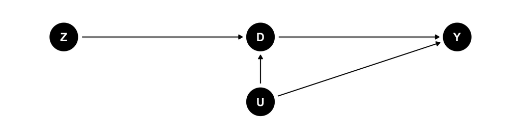

DAG (grafo acíclico direcionado): os nós representam variáveis e as setas indicam relações causais hipotéticas. Z: elegibilidade pelo sorteio; D: serviço militar; Y: rendimentos; U: fatores não observados.

- **Relevância:** $Z$ influencia $D$.
- **Exogeneidade:** $Z$ é independente de $U$.
- **Restrição de exclusão:** $Z$ afeta $Y$ somente por meio de $D$.

## Hipóteses no exemplo dos veteranos

Para utilizar a elegibilidade como instrumento do serviço militar, precisamos justificar três requisitos:

- **Relevância:** indivíduos elegíveis têm maior probabilidade de prestar serviço militar do que os não elegíveis.
- **Exogeneidade:** o sorteio torna plausível que a elegibilidade não esteja associada a características preexistentes que afetam os rendimentos.
- **Exclusão:** a elegibilidade deve afetar os rendimentos apenas por meio do serviço militar efetivamente prestado.

**Atenção:** a atribuição aleatória ajuda a fundamentar a exogeneidade, mas não garante a restrição de exclusão.

A estratégia explora a variação do serviço militar induzida pelo sorteio, mesmo que o serviço efetivo continue sujeito à seleção.

## A lógica do Método dos Momentos (Hill, Griffiths e Lim, 2018)

No exemplo do serviço militar, vimos **por que procurar um instrumento**. Agora precisamos compreender como construir um estimador a partir dessa estratégia.

O **Método dos Momentos (MM)** utiliza relações entre características da distribuição populacional, chamadas **momentos**, e parâmetros desconhecidos.

O procedimento envolve três passos:

1. **População:** estabelecer relações válidas entre momentos e parâmetros.
2. **Amostra:** substituir momentos populacionais por momentos amostrais.
3. **Estimação:** resolver as equações amostrais para obter os estimadores.

Começaremos com exemplos simples e, depois, aplicaremos essa lógica à construção dos estimadores **MQO e VI**.

## Momentos de uma distribuição

Os **momentos** descrevem características de uma distribuição por meio de esperanças matemáticas.

O momento **não centrado de ordem $r$** de uma variável $Y$ é:

$$E(Y^r), \qquad r=1,2,\ldots$$

quando essa esperança existe.

### Exemplos

- **Primeiro momento (média):** $E(Y)=\mu$.
- **Segundo momento não centrado:** $E(Y^2)$.

A variância e a covariância também podem ser expressas por esperanças:

$$\begin{aligned}
\operatorname{Var}(Y)&=E(Y^2)-[E(Y)]^2,\\[8pt]
\operatorname{Cov}(X,Y)&=E(XY)-E(X)E(Y).
\end{aligned}$$

No MM, utilizaremos relações envolvendo essas esperanças para estimar parâmetros desconhecidos.

## Momentos populacionais e amostrais

Os **momentos populacionais** caracterizam a distribuição de uma variável aleatória, mas geralmente são desconhecidos.

Com uma amostra aleatória $Y_1,\ldots,Y_N$, construímos seus **correspondentes amostrais**:

$$\begin{aligned}
E(Y)&\quad\longleftrightarrow\quad
\overline Y=\frac1N\sum_{i=1}^N Y_i,\\[12pt]
E(Y^2)&\quad\longleftrightarrow\quad
\frac1N\sum_{i=1}^N Y_i^2.
\end{aligned}$$

Os momentos amostrais são calculados a partir das observações e utilizados para estimar os momentos populacionais.

**Atenção:** essa correspondência não significa igualdade exata. Em uma amostra finita, os momentos amostrais podem diferir dos populacionais.

## Por que usar os momentos amostrais?

Uma versão da **Lei dos Grandes Números (LGN)** estabelece que, para observações independentes e identicamente distribuídas, com média $\mu$ e variância finita:

$$\overline Y\xrightarrow{p}E(Y_i)=\mu.$$

Isso significa que, à medida que $N$ aumenta, a probabilidade de a média amostral se afastar da média populacional por mais do que uma tolerância fixa tende a zero.

A mesma lógica se aplica a outros momentos amostrais, como a média dos quadrados, quando as condições correspondentes são satisfeitas.

**Consequência para o MM:** os momentos amostrais podem ser utilizados para aproximar os momentos populacionais envolvidos na construção dos estimadores.

## Uma condição de momento

No MM, uma **condição de momento** é uma relação populacional expressa como uma esperança igual a zero, satisfeita no valor verdadeiro do parâmetro.

Considere a média populacional desconhecida $\mu_0=E(Y_i)$. Pela linearidade da esperança:

$$\begin{aligned}
E(Y_i-\mu_0)
&=E(Y_i)-\mu_0\\[6pt]
&=\mu_0-\mu_0=0.
\end{aligned}$$

Portanto,

$$\boxed{E(Y_i-\mu_0)=0}$$

é uma **condição de momento válida** para a média populacional.

Essa relação vale na população, embora não conheçamos $\mu_0$. No próximo passo, utilizaremos sua contrapartida amostral para construir um estimador.

## Estimador MM da média

Partimos da condição de momento populacional:

$$E(Y_i-\mu_0)=0.$$

No MM, substituímos a esperança por uma **média amostral** e procuramos um valor $\mu$ que resolva a equação:

$$\begin{aligned}
\frac{1}{N}\sum_{i=1}^{N}(Y_i-\mu)&=0\\[8pt]
\overline Y-\mu&=0\\[8pt]
\mu&=\overline Y.
\end{aligned}$$

Portanto, o **estimador MM da média populacional** é:

$$\boxed{\widehat\mu_{\mathrm{MM}}=\overline Y.}$$

A equação amostral é satisfeita por construção pelo estimador. Isso não significa que $\overline Y=\mu_0$ em uma amostra finita.

## Parâmetro, estimador e estimativa

Considere uma amostra observada com cinco valores: $(5,10,9,14,7)$.

A média amostral calculada é:

$$\overline y=\frac{5+10+9+14+7}{5}=9.$$

- **Parâmetro:** $\mu_0$, a média populacional desconhecida.
- **Estimador:** $\widehat\mu_{\mathrm{MM}}=\overline Y$, uma função da amostra aleatória.
- **Estimativa:** $\overline y=9$, o valor obtido nesta amostra.

**Interpretação:** outra amostra poderia produzir uma estimativa diferente, embora o parâmetro populacional permanecesse o mesmo.

## MM para média e variância

Queremos estimar dois parâmetros: a **média** $\mu_0$ e a **variância** $\sigma_0^2$ de uma distribuição.

Utilizamos duas relações populacionais:

$$\begin{aligned}
E(Y_i)&=\mu_0,\\[10pt]
E(Y_i^2)&=\sigma_0^2+\mu_0^2.
\end{aligned}$$

No MM, substituímos as esperanças por seus correspondentes amostrais e obtemos um sistema de **duas equações**:

$$\begin{aligned}
\overline Y&=\mu,\\[10pt]
\frac1N\sum_{i=1}^NY_i^2&=\sigma^2+\mu^2.
\end{aligned}$$

As incógnitas $\mu$ e $\sigma^2$ serão determinadas pela resolução desse sistema.

## Estimadores MM da média e da variância

A primeira equação fornece diretamente o estimador da média:

$$\boxed{\widehat\mu_{\mathrm{MM}}=\overline Y.}$$

Substituindo essa solução na segunda equação:

$$\begin{aligned}
\frac1N\sum_{i=1}^NY_i^2
&=\widetilde\sigma_{\mathrm{MM}}^2+\overline Y^2\\[10pt]
\widetilde\sigma_{\mathrm{MM}}^2
&=\frac1N\sum_{i=1}^NY_i^2-\overline Y^2\\[10pt]
&=\frac1N\sum_{i=1}^N(Y_i-\overline Y)^2.
\end{aligned}$$

**Resultado:** o estimador MM da variância utiliza o denominador $N$, diferentemente da variância amostral usual, que utiliza $N-1$.

## Estimador MM da distribuição uniforme

Considere uma amostra aleatória de $X_i\sim U(0,\theta_0)$, com $\theta_0>0$.

Queremos estimar $\theta_0$, o **limite superior desconhecido** da distribuição.

O primeiro momento populacional fornece:

$$E(X_i)=\frac{\theta_0}{2}
\quad\Longleftrightarrow\quad
E\left(X_i-\frac{\theta_0}{2}\right)=0.$$

Substituímos a esperança por uma média amostral e resolvemos:

$$\begin{aligned}
\frac1N\sum_{i=1}^N\left(X_i-\frac{\theta}{2}\right)&=0\\[8pt]
\overline X-\frac{\theta}{2}&=0\\[8pt]
\boxed{\widehat\theta_{\mathrm{MM}}=2\overline X.}
\end{aligned}$$

## Validade e identificação

Para que as condições de momento permitam identificar parâmetros, precisamos de duas propriedades:

- **Validade:** as condições populacionais devem ser satisfeitas nos verdadeiros valores dos parâmetros.
- **Identificação:** somente os verdadeiros valores dos parâmetros devem satisfazer conjuntamente essas condições.

**Exemplo — distribuição uniforme:** como $E(X_i)=\theta_0/2$,

$$\begin{aligned}
E\left(X_i-\frac{\theta}{2}\right)
&=\frac{\theta_0-\theta}{2},\\[10pt]
E\left(X_i-\frac{\theta}{2}\right)=0
&\Longleftrightarrow \theta=\theta_0.
\end{aligned}$$

A condição é **válida** em $\theta_0$ e **identifica** um único valor para o parâmetro.

Na regressão, construiremos condições de momento a partir das hipóteses sobre o erro.

## O modelo e as condições utilizadas

Para compreender como o MM é aplicado à regressão, começaremos pela construção dos estimadores **MQO**.

Considere o modelo de regressão linear simples:

$$y_i=\beta_0+\beta_1x_i+\varepsilon_i.$$

Suponha que o erro satisfaça duas condições populacionais:

$$E(\varepsilon_i)=0,\qquad
\operatorname{Cov}(x_i,\varepsilon_i)=0.$$

A segunda condição estabelece que o regressor **não está correlacionado com o erro**.

Trabalharemos com uma amostra aleatória, momentos necessários finitos e $\operatorname{Var}(x_i)>0$.

Essas hipóteses permitirão construir as **condições de momento** utilizadas para obter os estimadores MQO.

## Covariância e condições de momento

Pela definição de covariância:

$$\operatorname{Cov}(x_i,\varepsilon_i)
=E(x_i\varepsilon_i)-E(x_i)E(\varepsilon_i).$$

Como $E(\varepsilon_i)=0$, obtemos:

$$\operatorname{Cov}(x_i,\varepsilon_i)=E(x_i\varepsilon_i).$$

Portanto, se $\operatorname{Cov}(x_i,\varepsilon_i)=0$, temos duas **condições de momento populacionais**:

$$\boxed{
E(\varepsilon_i)=0,\qquad E(x_i\varepsilon_i)=0.
}$$

Essas condições serão utilizadas para construir os estimadores MQO pelo Método dos Momentos.

## Estimação por MQO

### Condições populacionais

O erro populacional $\varepsilon_i$ não é diretamente observado. Pelo modelo de regressão:

$$\varepsilon_i=y_i-\beta_0-\beta_1x_i.$$

Substituímos essa expressão nas duas condições de momento, $E(\varepsilon_i)=0$ e $E(x_i\varepsilon_i)=0$:

$$\begin{aligned}
E(y_i-\beta_0-\beta_1x_i)&=0,\\[12pt]
E[x_i(y_i-\beta_0-\beta_1x_i)]&=0.
\end{aligned}$$

Essas condições populacionais são satisfeitas pelos **verdadeiros valores** de $\beta_0$ e $\beta_1$.

Elas envolvem variáveis observáveis e parâmetros desconhecidos, permitindo construir as equações amostrais de estimação.

## Estimação por MQO

### Equações amostrais

No MM, substituímos as esperanças populacionais por **médias amostrais** e procuramos valores $b_0$ e $b_1$ que satisfaçam:

$$\begin{aligned}
\frac1N\sum_{i=1}^N(y_i-b_0-b_1x_i)&=0,\\[12pt]
\frac1N\sum_{i=1}^Nx_i(y_i-b_0-b_1x_i)&=0.
\end{aligned}$$

As equações estabelecem que:

- A **média dos resíduos** deve ser zero.
- A **média dos produtos** entre $x_i$ e os resíduos deve ser zero.

Temos duas equações para duas incógnitas. Com variação de $x_i$ na amostra, o sistema determina os estimadores $b_0$ e $b_1$.

## Derivação de MQO

### Intercepto

Partimos da primeira equação amostral, que estabelece que a **média dos resíduos é zero**:

$$\frac1N\sum_{i=1}^N(y_i-b_0-b_1x_i)=0.$$

Desenvolvendo os termos:

$$\begin{aligned}
\frac1N\sum_i y_i-b_0-b_1\frac1N\sum_i x_i&=0\\[10pt]
\overline y-b_0-b_1\overline x&=0.
\end{aligned}$$

Isolando o intercepto:

$$\boxed{b_0=\overline y-b_1\overline x.}$$

Essa expressão determina $b_0$ **em função de $b_1$**. Para obter a inclinação, vamos substituí-la na segunda equação amostral.

## Derivação de MQO

### Inclinação

Partimos da segunda equação amostral, multiplicada por $N$:

$$\sum_i x_i(y_i-b_0-b_1x_i)=0.$$

Substituindo $b_0=\overline y-b_1\overline x$:

$$\begin{aligned}
0
&=\sum_i x_iy_i
-(\overline y-b_1\overline x)\sum_i x_i
-b_1\sum_i x_i^2\\[10pt]
&=\sum_i x_iy_i-N\overline x\overline y
-b_1\left(\sum_i x_i^2-N\overline x^2\right).
\end{aligned}$$

Utilizamos $\sum_i x_i=N\overline x$. Isolando $b_1$:

$$\boxed{
b_1=
\frac{\sum_i x_iy_i-N\overline x\overline y}
{\sum_i x_i^2-N\overline x^2}.
}$$

A inclinação pode ser determinada quando $x_i$ apresenta **variação na amostra**.

## Identidades em desvios das médias

Para reconhecer a fórmula usual de MQO, reescrevemos o numerador e o denominador em **desvios das médias**.

**Numerador:**

$$\begin{aligned}
\sum_i(x_i-\overline x)(y_i-\overline y)
={}&\sum_i x_iy_i-\overline y\sum_i x_i -\overline x\sum_i y_i+N\overline x\overline y\\[8pt]
={}&\sum_i x_iy_i-N\overline x\overline y.
\end{aligned}$$

**Denominador:**

$$\begin{aligned}
\sum_i(x_i-\overline x)^2
&=\sum_i x_i^2-2\overline x\sum_i x_i+N\overline x^2\\[8pt]
&=\sum_i x_i^2-N\overline x^2.
\end{aligned}$$

Em ambas as identidades, utilizamos $\sum_i x_i=N\overline x$ e $\sum_i y_i=N\overline y$.

## Reconhecendo os estimadores MQO

Substituindo as identidades em desvios das médias na expressão obtida para $b_1$:

$$\boxed{
\begin{aligned}
b_1&=\frac{\sum_i(x_i-\overline x)(y_i-\overline y)}
{\sum_i(x_i-\overline x)^2},\\[12pt]
b_0&=\overline y-b_1\overline x.
\end{aligned}
}$$

Obtivemos exatamente os **estimadores MQO** da regressão linear simples com intercepto.

Portanto, utilizando as condições de momento $E(\varepsilon_i)=0$ e $E(x_i\varepsilon_i)=0$, o **MM conduz aos mesmos estimadores que MQO**.

Essa equivalência algébrica não demonstra, por si só, a validade das condições populacionais.

## Erro populacional e resíduo estimado

O **erro populacional** depende dos parâmetros verdadeiros do modelo, enquanto o **resíduo estimado** utiliza os coeficientes obtidos por MQO:

$$\begin{aligned}
\varepsilon_i&=y_i-\beta_0-\beta_1x_i,\\[8pt]
\widehat\varepsilon_i&=y_i-b_0-b_1x_i.
\end{aligned}$$

Na regressão por MQO com intercepto, os resíduos satisfazem:

$$\sum_i\widehat\varepsilon_i=0,\qquad
\sum_i x_i\widehat\varepsilon_i=0.$$

Essas igualdades são satisfeitas **por construção**, mesmo quando $x_i$ é endógeno.

Já $E(x_i\varepsilon_i)=0$ é uma **condição populacional** que não decorre dessas propriedades dos resíduos.

## O que falha com a endogeneidade?

Considere que $E(\varepsilon_i)=0$, mas o regressor $x_i$ esteja correlacionado com o erro: $\operatorname{Cov}(x_i,\varepsilon_i)\neq0.$

Pela definição de covariância:

$$\begin{aligned}
E(x_i\varepsilon_i)
&=\operatorname{Cov}(x_i,\varepsilon_i)
+E(x_i)E(\varepsilon_i)\\[8pt]
&=\operatorname{Cov}(x_i,\varepsilon_i)\neq0.
\end{aligned}$$

Portanto, das duas condições de momento utilizadas para obter MQO:

- $E(\varepsilon_i)=0$ **permanece válida**.
- $E(x_i\varepsilon_i)=0$ **deixa de ser válida**.

Sob as condições usuais, MQO é inconsistente para $\beta_1$.

**Estratégia de VI:** substituir a condição inválida por outra baseada em um instrumento válido.

## Uma nova condição de momento

Se o instrumento $z_i$ satisfaz $E(\varepsilon_i)=0$ e $\operatorname{Cov}(z_i,\varepsilon_i)=0$, então:

$$\begin{aligned}
E(z_i\varepsilon_i)
&=\operatorname{Cov}(z_i,\varepsilon_i)
+E(z_i)E(\varepsilon_i)\\[8pt]
&=0.
\end{aligned}$$

Substituindo $\varepsilon_i=y_i-\beta_0-\beta_1x_i$:

$$\boxed{
E[z_i(y_i-\beta_0-\beta_1x_i)]=0.
}$$

Essa é a **condição de momento instrumental**, que substitui a condição inválida $E(x_i\varepsilon_i)=0$.

O instrumento substitui $x_i$ **na condição de momento**, não na equação estrutural.

## Estimação por VI

### Condições populacionais

Mantemos a condição $E(\varepsilon_i)=0$ e substituímos a condição inválida $E(x_i\varepsilon_i)=0$ pela condição instrumental $E(z_i\varepsilon_i)=0$.

Substituindo $\varepsilon_i=y_i-\beta_0-\beta_1x_i$:

$$\begin{aligned}
E(y_i-\beta_0-\beta_1x_i)&=0,\\[12pt]
E[z_i(y_i-\beta_0-\beta_1x_i)]&=0.
\end{aligned}$$

Temos **duas condições de momento** para identificar os dois parâmetros desconhecidos, $\beta_0$ e $\beta_1$.

Para garantir a identificação no modelo simples, também precisamos da **relevância do instrumento**:

$$\boxed{\operatorname{Cov}(z_i,x_i)\neq0.}$$

## Estimação por VI

### Equações amostrais

Substituímos as esperanças populacionais por **médias amostrais** e procuramos os estimadores $\widehat\beta_{0,\mathrm{VI}}$ e $\widehat\beta_{1,\mathrm{VI}}$ que resolvem:

$$\begin{aligned}
\frac1N\sum_i(y_i-\widehat\beta_{0,\mathrm{VI}}
-\widehat\beta_{1,\mathrm{VI}}x_i)&=0,\\[12pt]
\frac1N\sum_i z_i(y_i-\widehat\beta_{0,\mathrm{VI}}
-\widehat\beta_{1,\mathrm{VI}}x_i)&=0.
\end{aligned}$$

As equações estabelecem que:

- A **média dos resíduos** deve ser zero.
- A **média dos produtos** entre $z_i$ e os resíduos deve ser zero.

**Diferença em relação a MQO:** utilizamos $z_i$, em vez de $x_i$, na segunda equação amostral.

## Derivação de VI

### Intercepto

Da primeira equação amostral, que estabelece a **média dos resíduos igual a zero**, obtemos:

$$\overline y-\widehat\beta_{0,\mathrm{VI}}
-\widehat\beta_{1,\mathrm{VI}}\overline x=0.$$

Isolando o intercepto:

$$\boxed{
\widehat\beta_{0,\mathrm{VI}}
=\overline y-\widehat\beta_{1,\mathrm{VI}}\overline x.
}$$

A expressão tem a **mesma forma algébrica de MQO**, mas os valores estimados podem diferir porque a inclinação é obtida por VI.

Agora substituímos essa expressão na segunda equação amostral para determinar $\widehat\beta_{1,\mathrm{VI}}$.

## Derivação de VI

### Inclinação

Partimos da segunda equação amostral, multiplicada por $N$:

$$\sum_i z_i(y_i-\widehat\beta_{0,\mathrm{VI}}
-\widehat\beta_{1,\mathrm{VI}}x_i)=0.$$

Substituindo $\widehat\beta_{0,\mathrm{VI}} =\overline y-\widehat\beta_{1,\mathrm{VI}}\overline x$:

$$\begin{aligned}
0
={}&\sum_i z_iy_i
-(\overline y-\widehat\beta_{1,\mathrm{VI}}\overline x)
\sum_i z_i
-\widehat\beta_{1,\mathrm{VI}}\sum_i z_ix_i\\[8pt]
={}&\sum_i z_iy_i-N\overline z\overline y
-\widehat\beta_{1,\mathrm{VI}}
\left(\sum_i z_ix_i-N\overline z\overline x\right).
\end{aligned}$$

Utilizamos $\sum_i z_i=N\overline z$. Isolando a inclinação:

$$\boxed{
\widehat\beta_{1,\mathrm{VI}}
=\frac{\sum_i z_iy_i-N\overline z\overline y}
{\sum_i z_ix_i-N\overline z\overline x}.
}$$

## O estimador VI obtido por MM

Utilizamos as mesmas identidades em desvios das médias demonstradas anteriormente para MQO:

$$\begin{aligned}
\sum_i z_iy_i-N\overline z\overline y
&=\sum_i(z_i-\overline z)(y_i-\overline y),\\[10pt]
\sum_i z_ix_i-N\overline z\overline x
&=\sum_i(z_i-\overline z)(x_i-\overline x).
\end{aligned}$$

Substituindo na expressão obtida para a inclinação:

$$\boxed{
\widehat\beta_{1,\mathrm{VI}}
=\frac{\sum_i(z_i-\overline z)(y_i-\overline y)}
{\sum_i(z_i-\overline z)(x_i-\overline x)}
=\frac{\widehat{\operatorname{Cov}}(z,y)}
{\widehat{\operatorname{Cov}}(z,x)}
}$$

O intercepto é obtido pela primeira equação amostral:

$$\boxed{
\widehat\beta_{0,\mathrm{VI}}
=\overline y-\widehat\beta_{1,\mathrm{VI}}\overline x.
}$$

## Consistência do estimador VI

### Decomposição do estimador

Partimos do **estimador VI** obtido pelo Método dos Momentos e do **modelo estrutural**:

$$\widehat\beta_{1,\mathrm{VI}}
=\frac{\widehat{\operatorname{Cov}}(z,y)}
{\widehat{\operatorname{Cov}}(z,x)},
\qquad
y_i=\beta_0+\beta_1x_i+\varepsilon_i.$$

Substituindo o modelo estrutural no numerador e utilizando as propriedades da covariância amostral:

$$\widehat{\operatorname{Cov}}(z,y)
=\widehat{\operatorname{Cov}}
(z,\beta_0+\beta_1x+\varepsilon)
=\beta_1\widehat{\operatorname{Cov}}(z,x)
+\widehat{\operatorname{Cov}}(z,\varepsilon).$$

Logo, se $\widehat{\operatorname{Cov}}(z,x)\neq0$:

$$\widehat\beta_{1,\mathrm{VI}}
=\frac{\beta_1\widehat{\operatorname{Cov}}(z,x)
+\widehat{\operatorname{Cov}}(z,\varepsilon)}
{\widehat{\operatorname{Cov}}(z,x)}
=\boxed{\beta_1+
\frac{\widehat{\operatorname{Cov}}(z,\varepsilon)}
{\widehat{\operatorname{Cov}}(z,x)}}.$$

**Para demonstrar a consistência**, precisamos mostrar que a segunda parcela converge em probabilidade para zero.

## Consistência do estimador VI

### Limite em probabilidade

Da decomposição obtida anteriormente:

$$\widehat\beta_{1,\mathrm{VI}}
=\beta_1+
\frac{\widehat{\operatorname{Cov}}(z,\varepsilon)}
{\widehat{\operatorname{Cov}}(z,x)}.$$

Sob amostragem aleatória e momentos de segunda ordem finitos, a **Lei dos Grandes Números** garante:

$$\widehat{\operatorname{Cov}}(z,\varepsilon)
\xrightarrow{p}\operatorname{Cov}(z_i,\varepsilon_i),
\qquad
\widehat{\operatorname{Cov}}(z,x)
\xrightarrow{p}\operatorname{Cov}(z_i,x_i).$$

Pela **relevância**, $\operatorname{Cov}(z_i,x_i)\neq0$. Aplicando as propriedades dos limites em probabilidade:

$$\operatorname{plim}\widehat\beta_{1,\mathrm{VI}}
=\beta_1+
\frac{\operatorname{Cov}(z_i,\varepsilon_i)}
{\operatorname{Cov}(z_i,x_i)}.$$

Pela **exogeneidade**, $\operatorname{Cov}(z_i,\varepsilon_i)=0$. Portanto:

$$\boxed{\operatorname{plim}\widehat\beta_{1,\mathrm{VI}}=\beta_1.}$$

## Consistência do estimador VI

### Consistência dos estimadores

Demonstramos que, sob **relevância e exogeneidade** do instrumento, $\operatorname{plim}\widehat\beta_{1,\mathrm{VI}}=\beta_1$.

Para o **intercepto**, supondo também $E(\varepsilon_i)=0$:

$$\widehat\beta_{0,\mathrm{VI}}
=\overline y-\widehat\beta_{1,\mathrm{VI}}\overline x
\xrightarrow{p} E(y_i)-\beta_1E(x_i)=\beta_0.$$

**Comparando com MQO** (Aula 12), os limites em probabilidade dos estimadores da inclinação são:

$$\begin{aligned}
\operatorname{plim}\widehat\beta_{1,\mathrm{MQO}}
&=\beta_1+\frac{\operatorname{Cov}(x_i,\varepsilon_i)}
{\operatorname{Var}(x_i)},\\[12pt]
\operatorname{plim}\widehat\beta_{1,\mathrm{VI}}
&=\beta_1+\frac{\operatorname{Cov}(z_i,\varepsilon_i)}
{\operatorname{Cov}(z_i,x_i)}.
\end{aligned}$$

**Conclusão:** mesmo quando $x_i$ é endógeno, um instrumento **exógeno e relevante** permite obter estimadores VI consistentes.

## Inferência em grandes amostras

A **consistência** assegura que o estimador VI converge para o parâmetro verdadeiro. Para realizar inferência, precisamos também conhecer sua distribuição amostral.

Sob instrumentos válidos, identificação suficientemente forte e condições regulares, a estatística padronizada apresenta distribuição assintótica normal:

$$\frac{\widehat\beta_{1,\mathrm{VI}}-\beta_1}
{\widehat{\operatorname{se}}(\widehat\beta_{1,\mathrm{VI}})}
\xrightarrow{d}\mathcal N(0,1).$$

Essa aproximação permite construir, por exemplo, um **intervalo de confiança aproximado de 95%**:

$$\widehat\beta_{1,\mathrm{VI}}
\pm 1{,}96\,\widehat{\operatorname{se}}(\widehat\beta_{1,\mathrm{VI}}).$$

Os erros-padrão devem ser apropriados ao estimador **VI/MQ2E**. Instrumentos fracos podem comprometer a validade dessa aproximação.

## Por que a força do instrumento importa?

A **relevância** exige $\operatorname{Cov}(z_i,x_i)\neq0$, mas isso não garante estimativas suficientemente precisas.

Na regressão simples, sob homocedasticidade, a variância estimada convencional do estimador VI pode ser escrita como:

$$\widehat{\operatorname{Var}}(\widehat\beta_{1,\mathrm{VI}})
=\frac{\widehat\sigma^2_{\mathrm{VI}}}
{r_{zx}^{\,2}\sum_i(x_i-\overline x)^2}.$$

- $r_{zx}$: correlação amostral entre instrumento e regressor.
- $\widehat\sigma^2_{\mathrm{VI}}$: variância estimada do erro estrutural.

**Quanto menor a correlação em módulo**, maior a variância estimada, mantidos os demais componentes constantes.

Um instrumento fraco pode produzir estimativas imprecisas e comprometer testes e intervalos de confiança convencionais.

## Mínimos Quadrados em Dois Estágios

### Primeiro estágio

O **MQ2E** utiliza duas regressões para obter os coeficientes de VI.

No primeiro estágio, regredimos a variável endógena $x_i$ sobre o instrumento $z_i$:

$$x_i=\gamma_0+\gamma_1z_i+v_i.$$

Estimamos essa regressão por **MQO** e calculamos os valores ajustados:

$$\boxed{
\widehat x_i=\widehat\gamma_0+\widehat\gamma_1z_i.
}$$

Os valores $\widehat x_i$ representam a parte de $x_i$ **prevista linearmente pelo instrumento**.

No segundo estágio, utilizaremos $\widehat x_i$ como regressor para explicar $y_i$.

## Mínimos Quadrados em Dois Estágios

### Segundo estágio

No segundo estágio, regredimos $y_i$ sobre os valores ajustados $\widehat x_i$ do primeiro estágio, utilizando novamente **MQO**.

A regressão produz os coeficientes MQ2E:

$$\widehat y_i
=\widehat\beta_{0,\mathrm{MQ2E}}
+\widehat\beta_{1,\mathrm{MQ2E}}\widehat x_i.$$

No modelo simples com um instrumento para um regressor endógeno, obtemos exatamente os mesmos **coeficientes** do estimador VI:

$$\boxed{
\widehat\beta_{1,\mathrm{MQ2E}}
=\widehat\beta_{1,\mathrm{VI}}
}$$

**Atenção:** os erros-padrão calculados diretamente pela segunda regressão não são os erros-padrão apropriados para VI/MQ2E.

## Por que a segunda regressão isolada não basta?

A segunda regressão por MQO fornece os **coeficientes VI**, mas seus **erros-padrão usuais não são adequados**.

Isso ocorre porque os resíduos são diferentes:

$$\begin{aligned}
\widehat u_i^{(2)}
&=y_i-\widehat\beta_0-\widehat\beta_1\widehat x_i
&&\text{(segundo estágio)},\\[10pt]
\widehat\varepsilon_{i,\mathrm{VI}}
&=y_i-\widehat\beta_0-\widehat\beta_1x_i
&&\text{(modelo estrutural)}.
\end{aligned}$$

Observe que:

$$\widehat u_i^{(2)}
=\widehat\varepsilon_{i,\mathrm{VI}}
+\widehat\beta_1(x_i-\widehat x_i).$$

Portanto, os resíduos do segundo estágio incluem também os **erros de previsão do primeiro estágio**.

A inferência requer a **fórmula de variância apropriada para VI/MQ2E**, que utiliza os resíduos estruturais.

## Condições de momento excedentes

### Dois instrumentos

Até agora, utilizamos um instrumento para estimar o modelo $y_i=\beta_0+\beta_1x_i+\varepsilon_i$.

Suponha que dispomos de **dois instrumentos válidos**, $z_{1i}$ e $z_{2i}$. As condições populacionais são:

$$E(\varepsilon_i)=0,\qquad
E(z_{1i}\varepsilon_i)=0,\qquad
E(z_{2i}\varepsilon_i)=0.$$

Na amostra, tentaríamos satisfazer simultaneamente:

$$\sum_i\widehat\varepsilon_i=0,\qquad
\sum_i z_{1i}\widehat\varepsilon_i=0,\qquad
\sum_i z_{2i}\widehat\varepsilon_i=0,$$

com $\widehat\varepsilon_i =y_i-\widehat\beta_0-\widehat\beta_1x_i$.

Temos **três condições para apenas dois parâmetros**, $\beta_0$ e $\beta_1$. Em geral, não é possível satisfazer exatamente todas as equações amostrais.

Essa situação é chamada de sobreidentificação. Como utilizar conjuntamente as informações dos instrumentos?

## MQ2E com dois instrumentos

Com dois instrumentos para uma variável endógena, o **primeiro estágio** inclui ambos na mesma regressão:

$$x_i=\gamma_0+\gamma_1z_{1i}+\gamma_2z_{2i}+v_i.$$

Estimando por MQO, obtemos os valores ajustados:

$$\boxed{
\widehat x_i=\widehat\gamma_0+
\widehat\gamma_1z_{1i}+\widehat\gamma_2z_{2i}.
}$$

No **segundo estágio**, regredimos $y_i$ sobre $\widehat x_i$, obtendo os coeficientes MQ2E.

Assim, o MQ2E utiliza **conjuntamente** as informações dos dois instrumentos, sem exigir que todas as condições de momento amostrais sejam exatamente zero.

A validade dos instrumentos e sua relevância continuam sendo necessárias.

## VI com controles exógenos

Considere a **equação estrutural** com um controle exógeno:

$$y_i=\beta_0+\beta_1x_i+\delta w_i+\varepsilon_i.$$

- $x_i$: regressor **endógeno**, cujo coeficiente queremos estimar.
- $w_i$: controle **exógeno**, incluído na equação estrutural.
- $z_{1i},z_{2i}$: instrumentos **excluídos** da equação estrutural.

Como $w_i$ é exógeno, ele pode funcionar como **seu próprio instrumento** (instrumento incluído).

Os instrumentos $z_{1i}$ e $z_{2i}$ fornecem informação adicional para estimar o coeficiente de $x_i$, sem entrarem diretamente na equação estrutural.

## Os controles entram nos dois estágios

No modelo com controle exógeno $w_i$, ele deve participar dos **dois estágios do MQ2E**.

**Primeiro estágio:** regredimos $x_i$ nos instrumentos excluídos e no controle exógeno:

$$x_i=\gamma_0+\gamma_1z_{1i}
+\gamma_2z_{2i}+\gamma_3w_i+v_i.$$

Dessa regressão, obtemos os valores ajustados $\widehat x_i$.

**Segundo estágio:** regredimos $y_i$ em $\widehat x_i$ e mantemos o controle $w_i$:

$$\widehat y_i
=\widehat\beta_{0,\mathrm{MQ2E}}
+\widehat\beta_{1,\mathrm{MQ2E}}\widehat x_i
+\widehat\delta_{\mathrm{MQ2E}}w_i.$$

A **relevância dos instrumentos excluídos** deve ser avaliada após considerar a influência de $w_i$ sobre $x_i$.

## Diagnósticos da especificação VI

Considere o modelo com regressor endógeno $x_i$, controle exógeno $w_i$ e instrumentos externos $z_{1i},\ldots,z_{Li}$:

$$y_i=\beta_0+\beta_1x_i+\delta w_i+\varepsilon_i.$$

Três perguntas orientam a avaliação da especificação:

1. **Relevância — Teste F:** os instrumentos explicam $x_i$, após considerar $w_i$?
2. **Endogeneidade — Wu–Hausman:** há evidência de correlação entre $x_i$ e o erro estrutural?
3. **Sobreidentificação — Sargan:** as condições de momento excedentes são compatíveis com o modelo?

O teste de Sargan exige **mais instrumentos externos do que regressores endógenos**.

## Relevância dos instrumentos

### Hipóteses do teste F

Considere o **primeiro estágio**, com $L$ instrumentos externos e um controle exógeno:

$$x_i=\gamma_0+\sum_{\ell=1}^{L}\gamma_\ell z_{\ell i}
+\gamma_w w_i+v_i.$$

Queremos verificar se os instrumentos contribuem **conjuntamente** para explicar $x_i$ (relevância dos instrumentos), após considerar $w_i$. Testamos as hipóteses:

$$\begin{aligned}
H_0 &: \gamma_1=\gamma_2=\cdots=\gamma_L=0,\\[8pt]
H_1 &: \text{pelo menos um }\gamma_\ell\neq0.
\end{aligned}$$

- **Sob $H_0$:** os instrumentos não acrescentam poder explicativo linear ao primeiro estágio.
- **Sob $H_1$:** pelo menos um instrumento contribui para explicar $x_i$, após considerar $w_i$.

O teste F avalia os coeficientes dos instrumentos **conjuntamente**, mantendo o controle na regressão.

## Relevância dos instrumentos

### Estatística F

Comparamos o primeiro estágio **restrito** (sem os instrumentos externos) ao **completo** (com os instrumentos), mantendo o controle exógeno em ambos.

A estatística do teste é:

$$\boxed{
F=\frac{(SQR_R-SQR_U)/L}{SQR_U/(N-K_1)}.
}$$

- $SQR_R$ e $SQR_U$: somas dos quadrados dos resíduos dos modelos restrito e completo.
- $L$: número de instrumentos externos testados.
- $N$: tamanho amostral; $K_1$: número de coeficientes do primeiro estágio completo, incluindo a constante.

Sob $H_0$ e as hipóteses clássicas, $F\sim F_{L,N-K_1}$.

- **Significância:** $p<0{,}05$ indica rejeição de $H_0$.
- **Força instrumental:** $F>10$ é uma referência prática convencional, não uma garantia de instrumentos fortes.

## Teste de Wu–Hausman

### Hipóteses de exogeneidade

Se o regressor $x_i$ for exógeno, **precisamos utilizar VI em vez de MQO?**

Supondo instrumentos válidos, o teste de Wu–Hausman examina as hipóteses:

$$\begin{aligned}
H_0 &: \operatorname{Cov}(x_i,\varepsilon_i)=0,\\[8pt]
H_1 &: \operatorname{Cov}(x_i,\varepsilon_i)\neq0.
\end{aligned}$$

- **Sob $H_0$:** $x_i$ é exógeno. MQO e VI são consistentes, e a diferença entre os estimadores converge para zero.
- **Sob $H_1$:** $x_i$ é endógeno. MQO é inconsistente, enquanto VI permanece consistente.

A rejeição de $H_0$ fornece evidência de **endogeneidade**. A não rejeição não comprova que $x_i$ seja exógeno.

## Teste de Wu–Hausman

### Regressão auxiliar e hipótese testada

Queremos testar se $x_i$ está correlacionado com $\varepsilon_i$, mas **o erro estrutural não é observado**.

Com instrumentos e controle exógenos, essa possível correlação está associada à parte de $x_i$ não explicada no primeiro estágio.

Estimamos esse componente pelos resíduos $\widehat v_i=x_i-\widehat x_i$ e os incluímos em uma **regressão auxiliar por MQO**:

$$y_i=\beta_0+\beta_1x_i+\delta w_i
+\rho\widehat v_i+u_i.$$

Testamos o coeficiente dos resíduos:

$$\boxed{
H_0:\rho=0\qquad\text{contra}\qquad H_1:\rho\neq0.
}$$

A rejeição de $H_0$ fornece **evidência de endogeneidade**, pressupondo instrumentos válidos.

## Teste de Wu–Hausman

### Estatística e interpretação

Na regressão auxiliar, testamos $H_0:\rho=0$ utilizando a estatística:

$$t=\frac{\widehat\rho}
{\operatorname{se}(\widehat\rho)},
\qquad
\boxed{F=t^2.}$$

Como testamos **uma única restrição**, os testes $t$ bilateral e $F$ são equivalentes na inferência convencional.

Sob as hipóteses clássicas, $F\sim F_{1,N-K_A}$ sob $H_0$, sendo $K_A$ o número de coeficientes da regressão auxiliar.

**Decisão ao nível de significância de 5%:**

- **$p<0{,}05$:** rejeitamos $H_0$; há evidência de endogeneidade de $x_i$.
- **$p\geq0{,}05$:** não rejeitamos $H_0$; não há evidência estatística suficiente de endogeneidade.

A interpretação pressupõe **instrumentos válidos**. Não rejeitar $H_0$ não comprova exogeneidade.

## Teste de Sargan

### Hipóteses de sobreidentificação

Com uma variável endógena e $L>1$ instrumentos externos, o teste de Sargan utiliza as **$L-1$ restrições de sobreidentificação** para avaliar a **exogeneidade conjunta dos instrumentos**.

Instrumentos exógenos não estão correlacionados com o erro estrutural. Suas condições de momento são:

$$E(z_{1i}\varepsilon_i)
=E(z_{2i}\varepsilon_i)
=\cdots=E(z_{Li}\varepsilon_i)=0.$$

O teste de Sargan examina as hipóteses:

- **$H_0$:** todos os instrumentos externos são exógenos, isto é, não estão correlacionados com o erro estrutural.
- **$H_1$:** pelo menos um instrumento externo está correlacionado com o erro estrutural.

## Teste de Sargan

### Regressão auxiliar

Queremos examinar as condições de momento dos instrumentos, mas **o erro estrutural não é observado**.

Primeiro, calculamos os **resíduos estruturais** utilizando os coeficientes VI/MQ2E e o regressor observado $x_i$:

$$\widehat\varepsilon_i
=y_i-\widehat\beta_{0,\mathrm{VI}}
-\widehat\beta_{1,\mathrm{VI}}x_i
-\widehat\delta_{\mathrm{VI}}w_i.$$

Depois, regredimos esses resíduos sobre **todos os instrumentos externos e controles exógenos**:

$$\widehat\varepsilon_i
=a_0+a_ww_i+\sum_{\ell=1}^{L}a_\ell z_{\ell i}+r_i.$$

Se as condições de momento são válidas, não esperamos uma associação sistemática entre os instrumentos e o erro estrutural.

O teste de Sargan utiliza o **$R^2$ dessa regressão auxiliar** para avaliar as restrições de sobreidentificação.

## Teste de Sargan

### Estatística e interpretação

A estatística de Sargan utiliza o $R^2$ da **regressão auxiliar** apresentada anteriormente:

$$\boxed{J=NR^2.}$$

- $N$: tamanho da amostra.
- $R^2$: coeficiente de determinação da regressão auxiliar.

Sob $H_0$ e as condições convencionais do teste:

$$J\xrightarrow{d}\chi^2_{L-1}.$$

Com uma variável endógena e $L$ instrumentos externos, os **$L-1$ graus de liberdade** correspondem às restrições de sobreidentificação.

**Decisão ao nível de significância de 5%:**

- **$p<0{,}05$:** rejeitamos $H_0$; há evidência contrária às restrições de sobreidentificação.
- **$p\geq0{,}05$:** não rejeitamos $H_0$; os resultados são compatíveis com as restrições examinadas.

## Interpretação dos diagnósticos VI

Os três testes avaliam **aspectos distintos** da especificação por VI/MQ2E:

| Teste | O que investiga? | Rejeição de $H_0$ a 5% |
| --- | --- | --- |
| **F do primeiro estágio** | Os instrumentos externos contribuem conjuntamente para explicar $x_i$, após considerar os controles? | Há evidência de **relevância estatística conjunta** dos instrumentos. |
| **Wu–Hausman** | O regressor $x_i$ é endógeno? | Há evidência de **endogeneidade** de $x_i$. |
| **Sargan** | Os instrumentos satisfazem a condição de exogeneidade, isto é, de não correlação com o erro estrutural? | Há evidência de que **pelo menos um instrumento está correlacionado com o erro estrutural**, sob as hipóteses do teste. |

Regressão com Variáveis Instrumentais em R

## Demanda de peixe em Fulton

### Angrist, Graddy e Imbens (2000)

A estratégia estudada neste artigo procura identificar a demanda de peixe no mercado de Fulton, em Nova York.

**Pergunta:** qual é o efeito do preço sobre a quantidade demandada?

**Problema:** **Simultaneidade (causalidade reversa):** Preço e quantidade são determinados conjuntamente pela oferta e pela demanda. Choques de demanda alteram ambos, tornando o preço correlacionado com o erro da equação de demanda.

Ou seja, o preço é uma variável explicativa endógena.

## Instrumentos para o preço

### Demanda de peixe em Fulton

Condições de vento e ondas no mar afetam a pesca e deslocam a **oferta**, alterando os preços de equilíbrio.

Esses deslocamentos permitem observar diferentes equilíbrios ao longo da curva de demanda, **se** as condições meteorológicas não deslocarem a própria demanda e forem exógenas aos seus choques.

Os requisitos instrumentais precisam ser justificados por esse mecanismo econômico.

## Especificação da demanda

### Modelo em níveis

Utilizaremos a equação em níveis:

$$qty_t=\alpha+\beta\,price_t+\gamma\,t+\varepsilon_t.$$

- `qty_t`: quantidade de peixe vendida no dia (libras/dia).
- `price_t`: preço, tratado como endógeno (US$/libra).
- `t`: tendência temporal linear, tratada como controle exógeno (incluída para captar possíveis mudanças graduais na demanda, não explicadas pelo preço).

Esta especificação didática utiliza a estratégia instrumental do estudo; **não reproduz integralmente a especificação original do artigo**.

## Dados de Fulton

A base `fulton`, distribuída com `fixest`, contém **97 dias de negociação**.

| Variável | Significado na aplicação |
| --- | --- |
| `qty` | Quantidade vendida, em libras/dia. |
| `price` | Preço médio ponderado, em US$/libra. |
| `t` | Índice da tendência temporal linear. |
| `speed2` | Mínimo da velocidade do vento nos dois dias anteriores. |
| `wave2` | Média das alturas máximas das ondas nos dois dias anteriores. |

`speed2` e `wave2` são os instrumentos externos do preço.

## Estimação VI/MQ2E com `fixest`

### Sintaxe da função `feols()`

A função `fixest::feols()` estima modelos de regressão linear por MQO e, quando são especificadas variáveis instrumentais, por VI/MQ2E.

```r
fixest::feols(y ~ x1 | x2 ~ z1 + z2, data = dados)
```

**Componentes da fórmula:**

- **`y ~ x1`:** `y` é a variável dependente e `x1` é uma variável explicativa exógena.
- **`x2 ~ z1 + z2`:** `x2` é a variável explicativa endógena; `z1` e `z2` são os instrumentos.
- **`|`:** separa, nesta sintaxe, os regressores exógenos da especificação instrumental.

**Argumento `data`:** identifica o objeto `dados` que contém as variáveis utilizadas na estimação.

Na estimação por VI, a função executa automaticamente os **dois estágios do MQ2E** e calcula os erros-padrão correspondentes ao estimador.

## Angrist, Graddy e Imbens (2000)

### Estimação por MQO e VI/MQ2E em R

```r
# Carrega os dados do mercado de Fulton.
data("fulton", package = "fixest")

# As duas estimações utilizam erros-padrão convencionais (vcov = "iid").

# Estima a demanda por MQO, incluindo o preço e a tendência temporal.
modelo_mqo <- fixest::feols(
  qty ~ price + t,
  data = fulton,
  vcov = "iid"
)

# Estima por MQ2E, usando vento e ondas como instrumentos do preço.
modelo_vi <- fixest::feols(
  qty ~ t | price ~ speed2 + wave2,
  data = fulton,
  vcov = "iid"
)
```

## Estimação por MQO e VI/MQ2E em R

### Primeiro estágio

```r
# Exibe a regressão do primeiro estágio
summary(modelo_vi, stage = 1)
```

```
TSLS estimation: First stage
|- D.V.   : qty
|- Endo.  : price
|- Instr. : speed2, wave2
Dep. Var.: price
Observations: 97
Standard-errors: IID
             Estimate Std. Error   t value   Pr(>|t|)
(Intercept)  0.499222   0.131034  3.809861 2.4943e-04 ***
speed2      -0.007625   0.008984 -0.848762 3.9819e-01
wave2        0.103917   0.020432  5.086082 1.8899e-06 ***
t           -0.001831   0.001100 -1.664809 9.9317e-02 .
---
Signif. codes:  0 '***' 0.001 '**' 0.01 '*' 0.05 '.' 0.1 ' ' 1
RMSE: 0.2838   Adj. R2: 0.290336
F-test (1st stage): stat = 15.318, p = 1.777e-6, on 2 and 93 DoF.
```

```r
# Exibe a estimativa MQO do coeficiente do preço.
coef(modelo_mqo)["price"]
```

```
    price
-2325.964
```

## Angrist, Graddy e Imbens (2000)

### Primeiro estágio: relevância dos instrumentos

O primeiro estágio explica o preço pelos instrumentos meteorológicos, controlando pela tendência temporal:

$$price_t = \pi_0 + \pi_1 speed2_t + \pi_2 wave2_t + \pi_3 t + v_t.$$

**Resultados individuais:**

- `speed2`: coeficiente de $-0{,}0076$ ($p=0{,}398$), não significativo a 5%.
- `wave2`: coeficiente de $0{,}1039$ ($p<0{,}001$), significativo a 5%.

Teste F de relevância conjunta dos instrumentos:

$$\begin{aligned}
H_0 &: \pi_1=\pi_2=0,\\
H_1 &: \text{pelo menos um desses coeficientes é diferente de zero}.
\end{aligned}$$

$$F(2,93)=15{,}318,\qquad p<0{,}001.$$

**Conclusão:** rejeitamos $H_0$. Os instrumentos `speed2` e `wave2` são conjuntamente relevantes para explicar o preço, após controlar pela tendência temporal.

## Estimação por MQO e VI/MQ2E em R

### Segundo estágio

```r
# Exibe a regressão do segundo estágio
summary(modelo_vi, stage = 2)
```

```
TSLS estimation: Second stage
|- D.V.   : qty
|- Endo.  : price
|- Instr. : speed2, wave2
Dep. Var.: qty
Observations: 97
Standard-errors: IID
               Estimate Std. Error   t value   Pr(>|t|)
(Intercept)  7158.76801  1705.0985  4.198448 6.1008e-05 ***
fit_price   -3206.36184  1586.9124 -2.020503 4.6176e-02 *
t              -6.41882    10.8445 -0.591897 5.5534e-01
---
Signif. codes:  0 '***' 0.001 '**' 0.01 '*' 0.05 '.' 0.1 ' ' 1
RMSE: 2,506.1   Adj. R2: 0.022745
F-test (1st stage), price: stat = 15.31791, p = 1.777e-6, on 2 and 93 DoF.
               Wu-Hausman: stat =  0.41207, p = 0.522502, on 1 and 93 DoF.
                   Sargan: stat =  1.66746, p = 0.196599, on 1 DoF.
```

```r
# summary(modelo_vi) exibe apenas o segundo estágio
# por padrão
```

## Angrist, Graddy e Imbens (2000)

### Segundo estágio: efeito do preço sobre a demanda

Equação estimada por VI/MQ2E:

$$\widehat{qty}_t = 7158{,}77 - 3206{,}36\,price_t - 6{,}42\,t.$$

Efeito marginal do preço: $\widehat{\beta}_{VI}=-3206{,}36$.

- Erro-padrão (IID): $1586{,}91$.
- Estatística $t=-2{,}02$; valor-p $=0{,}046$.

O coeficiente é negativo e estatisticamente significativo a 5%.

**Interpretação econômica:** sob as hipóteses de identificação por VI, um aumento de **US$ 0,10/libra** implica uma redução estimada de aproximadamente **321 libras/dia** na quantidade demandada, mantendo `t` constante.

Como o modelo utiliza variáveis em níveis, o coeficiente representa um efeito marginal, não uma elasticidade-preço.

## Angrist, Graddy e Imbens (2000)

### Teste de endogeneidade de Wu–Hausman

**Comparação dos estimadores:** MQO: $\widehat{\beta}_{MQO}=-2325{,}96$; VI/MQ2E: $\widehat{\beta}_{VI}=-3206{,}36$.

O teste de Wu–Hausman investiga se há evidência de endogeneidade do preço.

**Procedimento:** acrescenta-se o resíduo do primeiro estágio ($\widehat{v}_t$) à regressão de demanda:

$$qty_t=\alpha+\beta\,price_t+\gamma\,t+\rho\,\widehat{v}_t+\varepsilon_t.$$

**Hipóteses:**

$$\begin{aligned}
H_0 &: \rho=0 && \text{(preço exógeno)},\\
H_1 &: \rho\neq0 && \text{(preço endógeno)}.
\end{aligned}$$

**Resultado:** $F(1,93)=0{,}4121$, com $p=0{,}5225$.

**Conclusão:** não rejeitamos $H_0$ ao nível de 5%. O teste não encontra evidência estatística suficiente de endogeneidade do preço nessa especificação.

Isso não fornece evidência para considerar o MQO inconsistente por endogeneidade.

## Angrist, Graddy e Imbens (2000)

### Teste de sobreidentificação de Sargan

**Objetivo:** avaliar a validade dos instrumentos em um modelo sobreidentificado.

O modelo utiliza dois instrumentos (`speed2` e `wave2`) para uma variável endógena (`price`), resultando em uma restrição de sobreidentificação.

**Hipóteses:**

$$\begin{aligned}
H_0 &: \text{os instrumentos são válidos},\\
H_1 &: \text{pelo menos um instrumento é inválido}.
\end{aligned}$$

**Resultado:** $\chi^2(1)=1{,}6675$, com $p=0{,}1966$.

**Conclusão:** não rejeitamos $H_0$ ao nível de 5%. O teste de Sargan não encontra evidência estatística contra a validade dos instrumentos utilizados.

## Angrist, Graddy e Imbens (2000)

### Síntese dos resultados econométricos

Efeito estimado por VI/MQ2E:

- Efeito marginal do preço: $\widehat{\beta}_{VI}=-3206{,}36$ ($p=0{,}046$).
- Um aumento de **US$ 0,10/libra** corresponde a uma redução média estimada de **321 libras/dia** na quantidade demandada, mantendo `t` constante.

**Diagnósticos de especificação:**

- **Teste F:** $F(2,93)=15{,}32$; $p<0{,}001$. Os instrumentos são conjuntamente relevantes.
- **Wu–Hausman:** $p=0{,}5225$. Não rejeitamos a hipótese de exogeneidade do preço.
- **Sargan:** $p=0{,}1966$. Não encontramos evidência estatística contra a validade dos instrumentos.

**Conclusão empírica:** embora preço e quantidade sejam determinados simultaneamente, o VI/MQ2E permite estimar a equação estrutural de demanda sem estimar conjuntamente a oferta.

Sob as hipóteses de identificação, encontramos um efeito marginal negativo e estatisticamente significativo do preço sobre a quantidade demandada.

Atividade 12

## Atividade 12 — Reprodução da aplicação em R

**Objetivo:** reproduzir a estimação da demanda de peixe no mercado de Fulton apresentada nesta aula.

Crie um documento Quarto chamado **`12-atividade.qmd`**, com formato de saída **HTML**, contendo o código R utilizado na aplicação de variáveis instrumentais.

O documento deverá:

1. Carregar a base de dados `fulton`, do pacote `fixest`.
2. Estimar o modelo de demanda por **MQO**.
3. Estimar o modelo por **VI/MQ2E**, utilizando `speed2` e `wave2` como instrumentos do preço.
4. Utilizar as mesmas especificações e a matriz de covariância `vcov = "iid"` apresentadas nos slides.

**Importante:** reproduza os procedimentos da aula, sem modificar as especificações econométricas.

## Atividade 12 — Resultados e entrega

O documento HTML deverá apresentar o **código R executado** e os respectivos resultados, incluindo:

- **Primeiro estágio:** `summary(modelo_vi, stage = 1)`.
- **Coeficiente do preço por MQO:** `coef(modelo_mqo)["price"]`.
- **Segundo estágio:** `summary(modelo_vi, stage = 2)`.

**Requisitos:**

- Organizar o documento com títulos e seções apropriados.
- Exibir os resultados produzidos pela execução do código, sem inseri-los manualmente.
- Renderizar o documento em HTML, sem erros de execução.
- Conferir se as estimativas reproduzem os resultados apresentados na aula, respeitados os arredondamentos.

**Entrega:** `12-atividade.qmd` e o arquivo HTML gerado.

## Referências

ANGRIST, J. D. [Lifetime Earnings and the Vietnam Era Draft Lottery: Evidence from Social Security Administrative Records](https://www.jstor.org/stable/2006679). **American Economic Review**, v. 80, n. 3, p. 313–336, 1990.

ANGRIST, J. D.; GRADDY, K.; IMBENS, G. W. [The Interpretation of Instrumental Variables Estimators in Simultaneous Equations Models with an Application to the Demand for Fish](https://doi.org/10.1111/1467-937X.00141). **The Review of Economic Studies**, v. 67, n. 3, p. 499–527, 2000.

ANGRIST, J. D.; PISCHKE, J.-S. [The Credibility Revolution in Empirical Economics: How Better Research Design Is Taking the Con out of Econometrics](https://doi.org/10.1257/jep.24.2.3). **Journal of Economic Perspectives**, v. 24, n. 2, p. 3–30, 2010.

HILL, R. C.; GRIFFITHS, W. E.; LIM, G. C. **Principles of Econometrics**. 5. ed. Hoboken, NJ: Wiley, 2018.

LEAMER, E. E. [Let’s Take the Con Out of Econometrics](https://www.jstor.org/stable/1803924). **The American Economic Review**, v. 73, n. 1, p. 31–43, 1983.

PEARL, J. [Causal Diagrams for Empirical Research](https://doi.org/10.1093/biomet/82.4.669). **Biometrika**, v. 82, n. 4, p. 669–688, 1995.

RUBIN, D. B. [Estimating Causal Effects of Treatments in Randomized and Nonrandomized Studies](https://doi.org/10.1037/h0037350). **Journal of Educational Psychology**, v. 66, n. 5, p. 688–701, 1974.